# Chapter03-2

Xiaoyan Yue

4/30/2017

```r
knitr::opts_chunk$set(echo = TRUE, cache= TRUE, autodep = TRUE)
library(tidyverse)
library(gridExtra)
```

# 3.6 Geometric objects

## geom_smooth

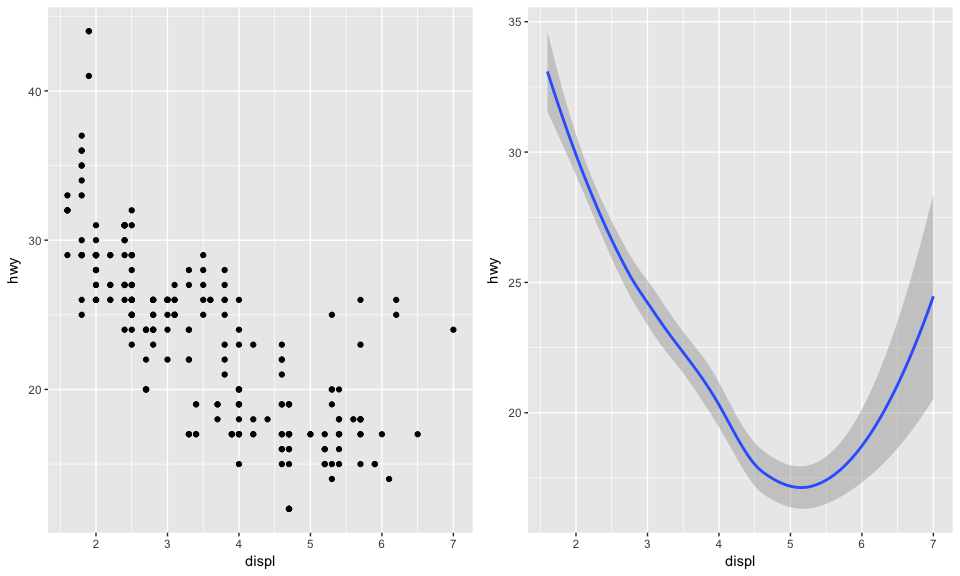

```r
#par(mfcol=c(1:2))
plot1 <- ggplot(data = mpg) +
  geom_point(mapping = aes(x = displ, y = hwy))

plot2 <- ggplot(data = mpg) +
  geom_smooth(mapping = aes(x = displ, y = hwy))

grid.arrange(plot1, plot2, nrow=1, ncol=2)
```

## More aesthetic for geom_smooth

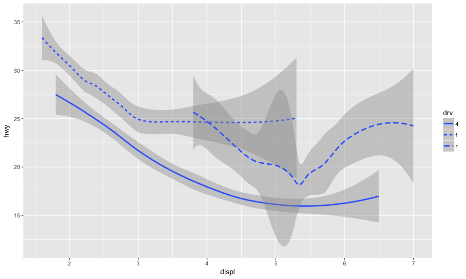

```r
ggplot(data = mpg) +
  geom_smooth(mapping = aes(x = displ, y = hwy, linetype = drv))#linetype
```

## Overlaying the lines on top of the raw data and then coloring everything according to drv

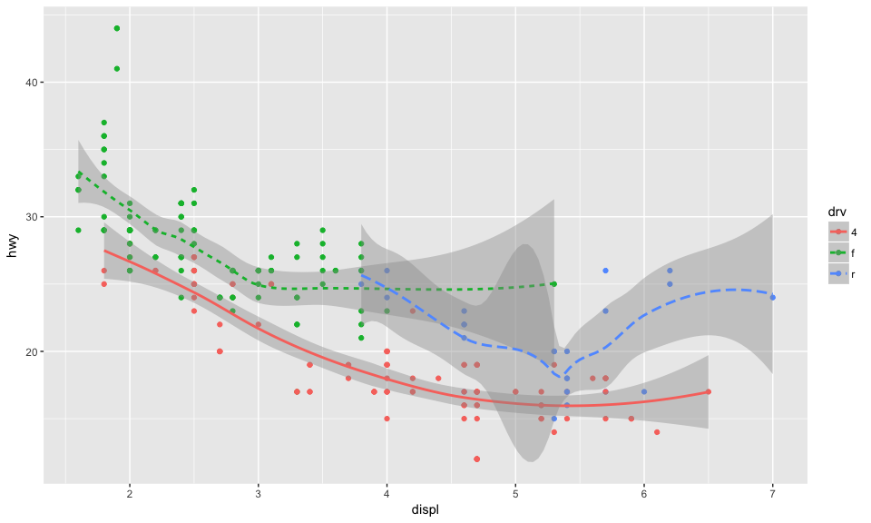

```r
ggplot(data = mpg) +
  geom_point(mapping = aes(x = displ, y = hwy, color = drv)) +
  geom_smooth(mapping = aes(x = displ, y = hwy, linetype = drv, color = drv))
```

## Group

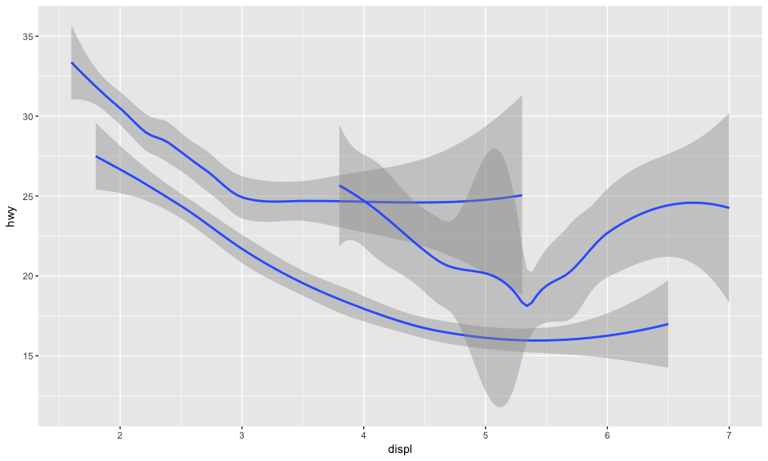

```r
ggplot(data = mpg) +
  geom_smooth(mapping = aes(x = displ, y = hwy, group = drv))#No legend as linestyle
```

## Display mutiple genoms in the same plot, 2 ways

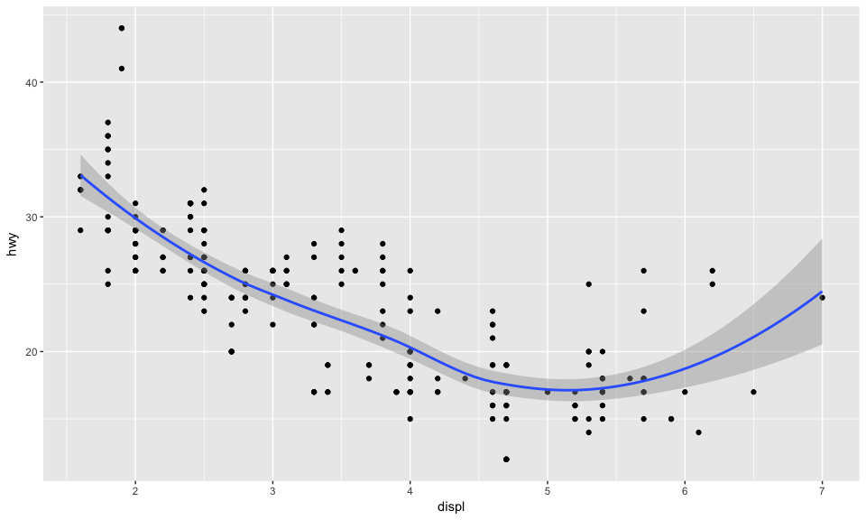

```r
ggplot(data = mpg) +
  geom_point(mapping = aes(x = displ, y = hwy)) +
  geom_smooth(mapping = aes(x = displ, y = hwy))#introduces some duplication
```

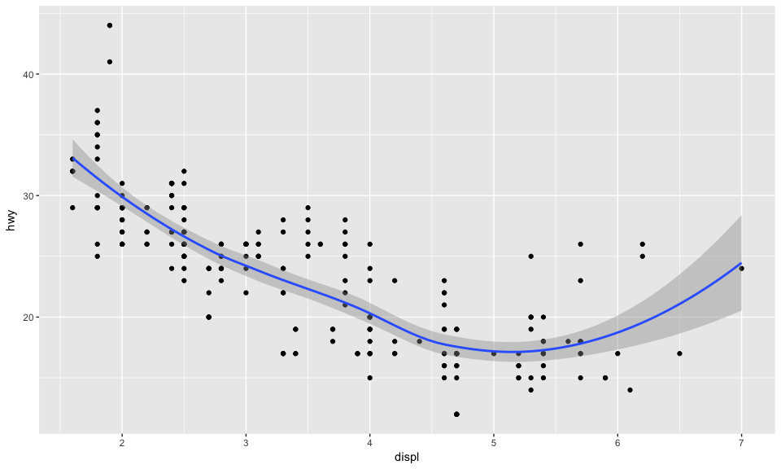

```r
ggplot(data = mpg, mapping = aes(x = displ, y = hwy)) +
  geom_point() +
  geom_smooth()
```

## Display different aesthetics in different layers

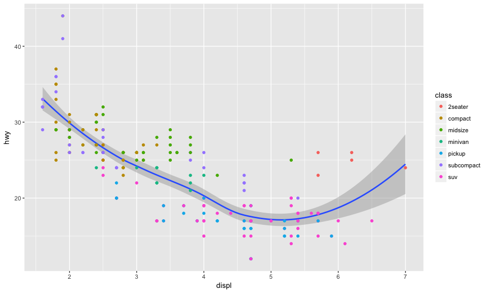

```r
ggplot(data = mpg, mapping = aes(x=displ, y=hwy)) +
  geom_smooth() +
  geom_point(mapping = aes(color=class))
```

## Try filter in plotting

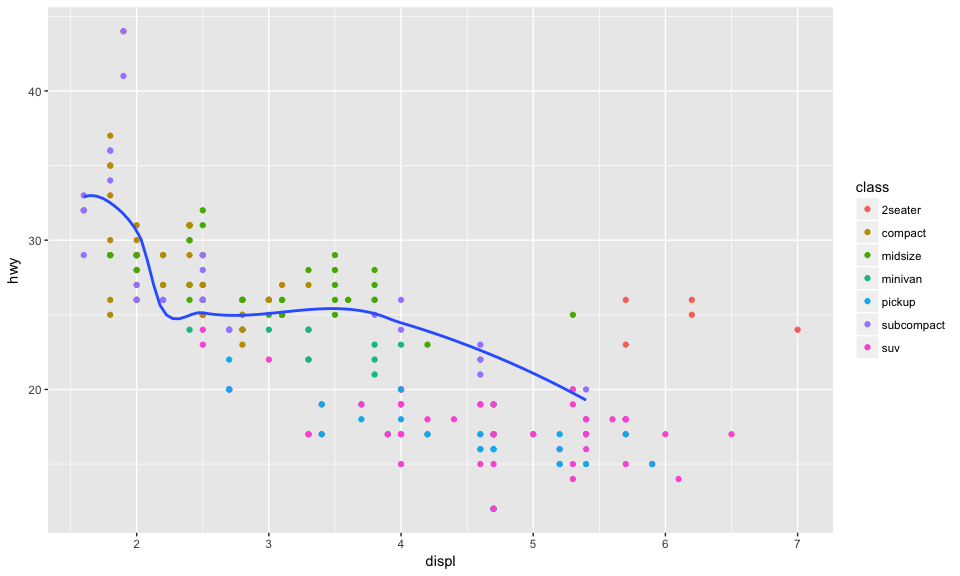

```r
ggplot(data = mpg, mapping = aes(x = displ, y = hwy)) +
  geom_point(mapping = aes(color = class)) +
  geom_smooth(data = filter(mpg, class == "subcompact"), se = FALSE)
```

# 3.7 Statistical transformations

## New dataset for bar charts

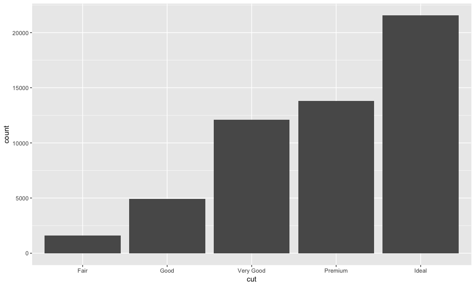

```r
ggplot(data = diamonds) +
  geom_bar(mapping = aes(x = cut))
```

```r
#Many graphs, like scatterplots, plot the raw values of your dataset. Other graphs, like bar charts, calculate new values to plot
```

## stat_count

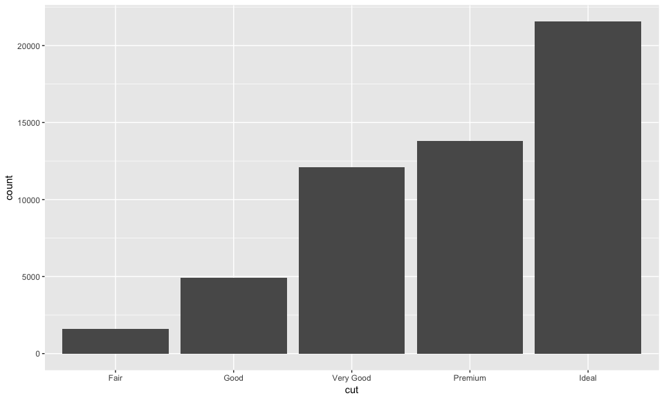

```r
ggplot(data = diamonds) +
  stat_count(mapping = aes(x = cut))
```

```r
#This works because every geom has a default stat; and every stat has a default geom.
```

## Try to change the default stat in geom_bar

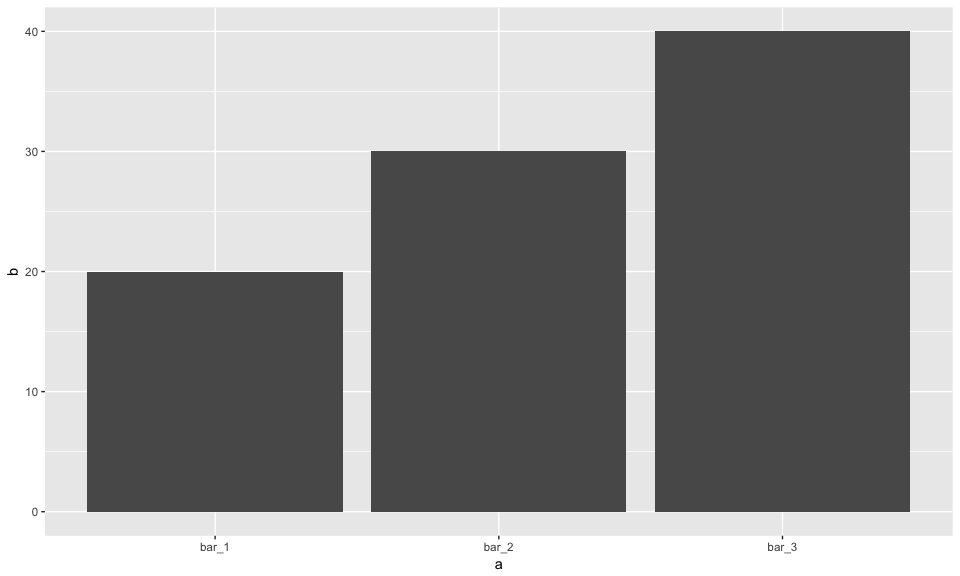

```r
demo <- tribble(
  ~a,      ~b,
  "bar_1", 20,
  "bar_2", 30,
  "bar_3", 40
)

ggplot(data = demo) +
  geom_bar(mapping = aes(x = a, y = b), stat = "identity")
```

```r
#This lets us map the height of the bars to the raw values of a y variable
```

## Try to change the default count to probability

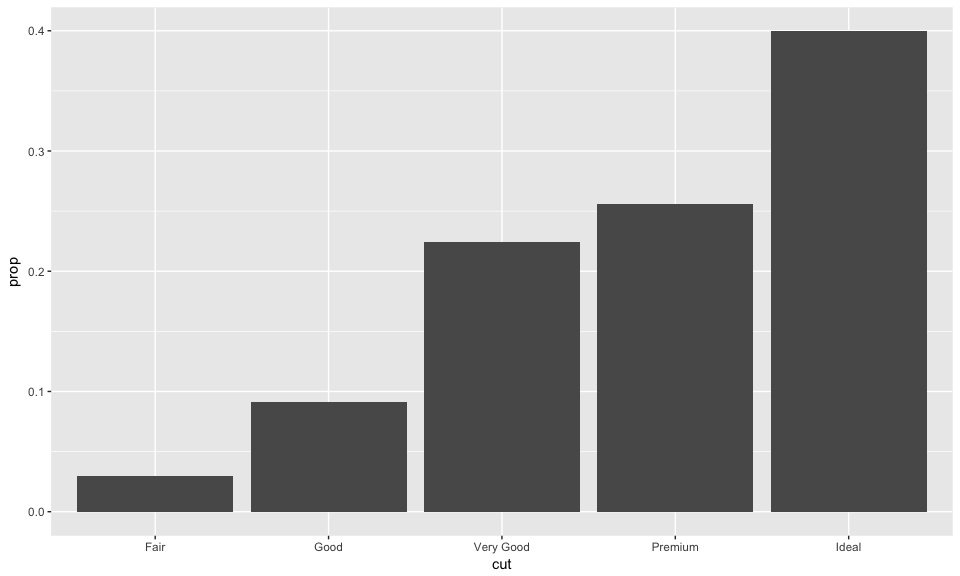

```r
ggplot(data = diamonds) +
  geom_bar(mapping = aes(x = cut, y = ..prop.., group = 1))
```

## Try to draw greater attention for statistical transformation

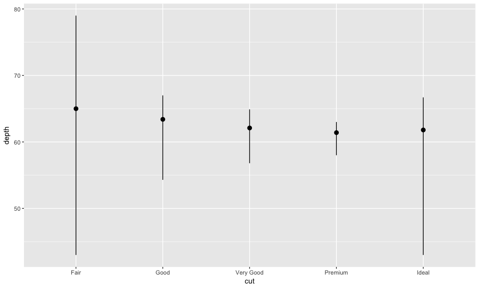

```r
ggplot(data = diamonds) +
  stat_summary(
    mapping = aes(x = cut, y = depth),
    fun.ymin = min,
    fun.ymax = max,
    fun.y = median
  )
```

```r
#ggplot2 provides over 20 stats for you to use. Each stat is a function
#?stat_bin
```

# 3.8 Position adjustment

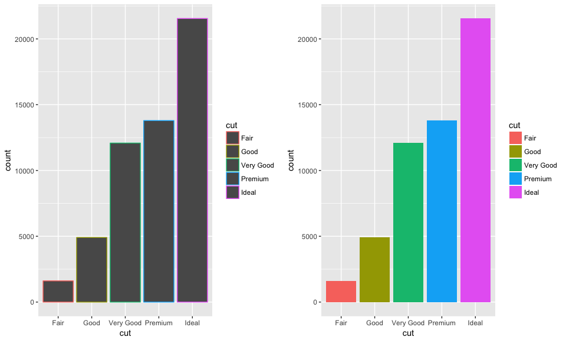

```r
pl1 <- ggplot(data = diamonds) +
  geom_bar(mapping = aes(x = cut, colour = cut))
pl2 <- ggplot(data = diamonds) +
  geom_bar(mapping = aes(x = cut, fill = cut))
grid.arrange(pl1,pl2,nrow=1,ncol=2)
```

## Try to map the fill aesthetic to another variable and do the ‘position’ adjustment in last plotting

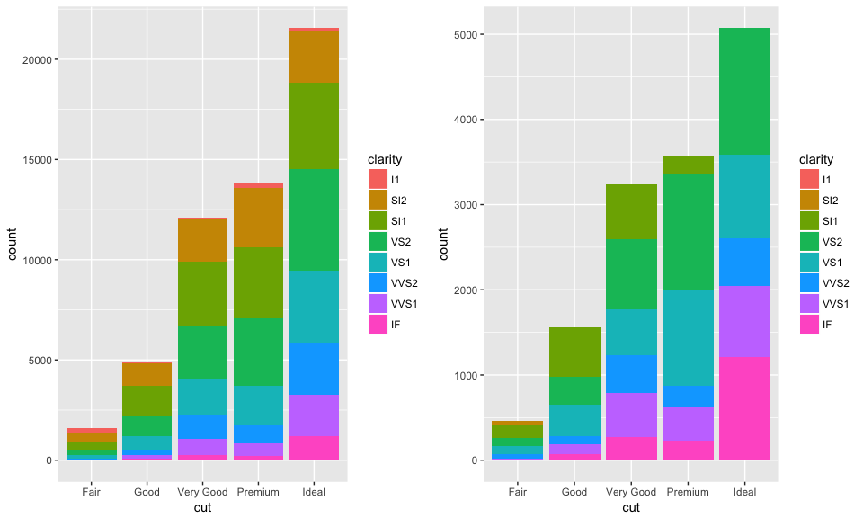

```r
ql1 <- ggplot(data = diamonds) +
  geom_bar(mapping = aes(x = cut, fill = clarity))

ql2 <- ggplot(data = diamonds) +
  geom_bar(mapping = aes(x = cut, fill = clarity), position = "identity")

grid.arrange(ql1,ql2,nrow=1,ncol=2)
```

```r
#position = "identity" will place each object exactly where it falls in the context of the graph. This is not very useful for bars, because it overlaps them.
```

## Look at the overlapping and fill=NA

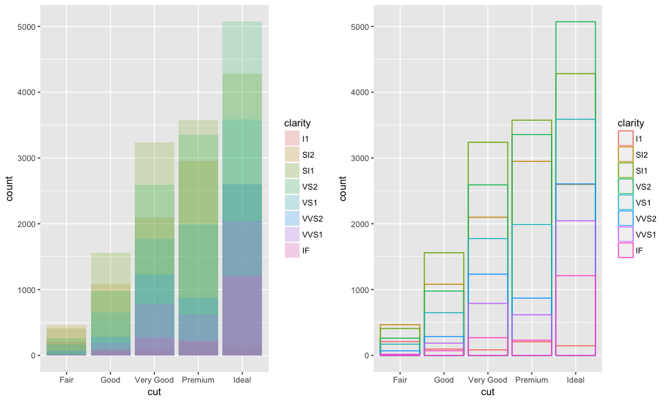

```r
ll1 <- ggplot(data = diamonds, mapping = aes(x = cut, fill = clarity)) +
  geom_bar(alpha = 1/5, position = "identity")
ll2 <- ggplot(data = diamonds, mapping = aes(x = cut, colour = clarity)) +
  geom_bar(fill = NA, position = "identity")

grid.arrange(ll1,ll2,nrow=1,ncol=2)
```

## Compare position=“fill” and position=“dodge”

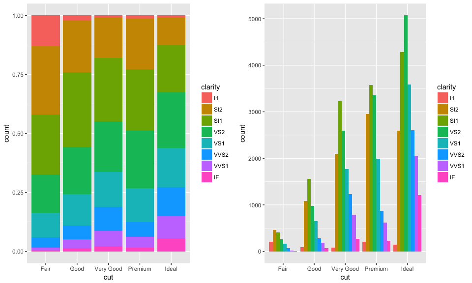

```r
al1 <- ggplot(data=diamonds) +
  geom_bar(mapping = aes(x=cut,fill=clarity),position = "fill")
al2 <- ggplot(data=diamonds) +
  geom_bar(mapping = aes(x=cut,fill=clarity),position = "dodge")
grid.arrange(al1,al2,nrow=1,ncol=2)
```

## How to deal with overplotting in scatterplot by position=“jitter”

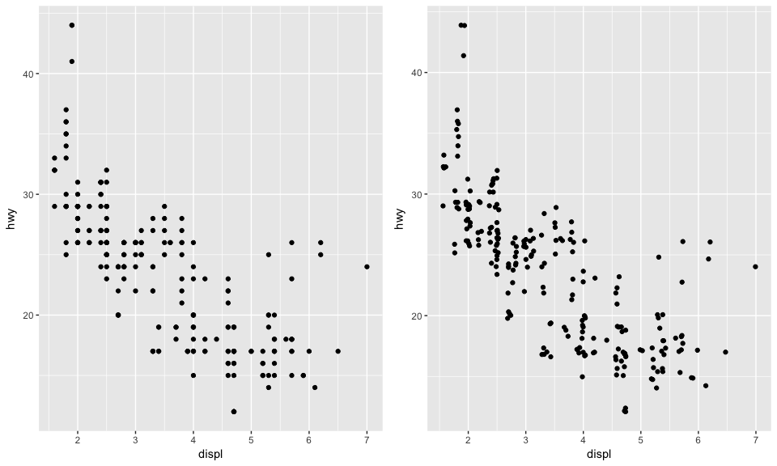

```r
bl1 <- ggplot(data = mpg) +
  geom_point(mapping = aes(x = displ, y = hwy))
bl2 <- ggplot(data = mpg) +
  geom_point(mapping = aes(x = displ, y = hwy), position = "jitter")
grid.arrange(bl1,bl2,nrow=1,ncol=2)
```

# 3.9 Coordinate systems

## coord_flip() switches the x and y axes

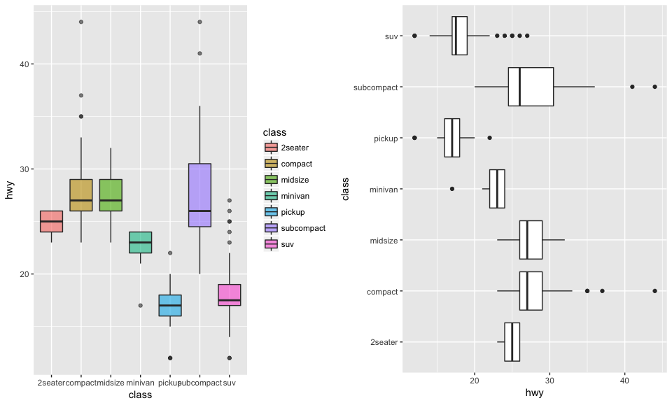

```r
cl1 <- ggplot(data = mpg, mapping = aes(x = class, y = hwy)) +
  geom_boxplot(mapping = aes(fill=class),alpha=3/5)
cl2 <- ggplot(data = mpg, mapping = aes(x = class, y = hwy)) +
  geom_boxplot() +
  coord_flip()
grid.arrange(cl1,cl2,nrow=1,ncol=2)
```

## coord_polar() uses polar coordinates

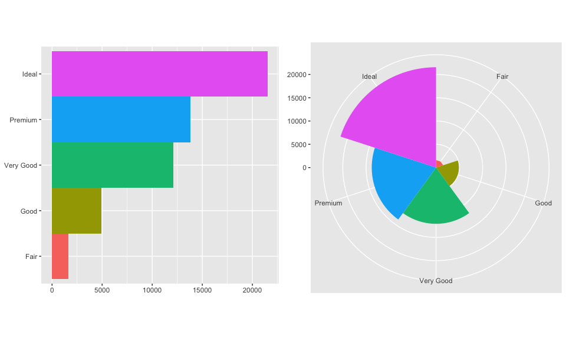

```r
bar <- ggplot(data = diamonds) +
  geom_bar(
    mapping = aes(x = cut, fill = cut),
    show.legend = FALSE,
    width = 1
  ) +
  theme(aspect.ratio = 1) +
  labs(x = NULL, y = NULL)

bar1 <- bar + coord_flip()
bar2 <- bar + coord_polar()

grid.arrange(bar1,bar2,nrow=1,ncol=2)
```

# Exercises

## 3.6.1

### 1. What geom would you use to draw a line chart? A boxplot? A histogram? An area chart?

### 2. Run this code in your head and predict what the output will look like. Then, run the code in R and check your predictions.

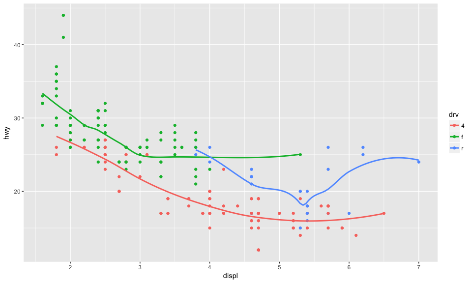

```r
ggplot(data = mpg, mapping = aes(x = displ, y = hwy, color = drv)) +
  geom_point() +
  geom_smooth(se = FALSE)
```

## 3. What does show.legend = FALSE do? What happens if you remove it?

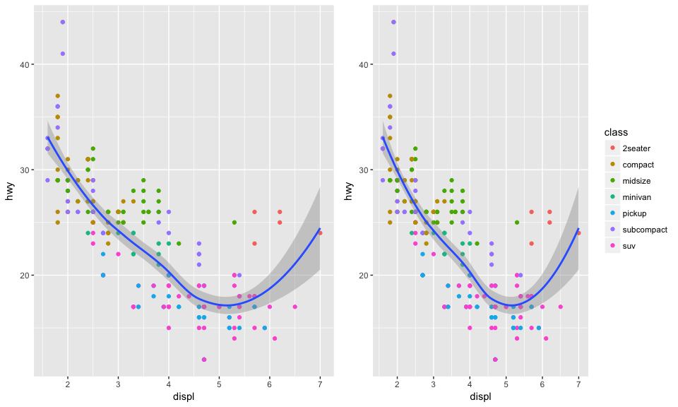

```r
#logical. Should this layer be included in the legends? NA, the default, includes if any aesthetics are mapped. FALSE never includes, and TRUE always includes.
Q1 <- ggplot(data = mpg, mapping = aes(x = displ, y = hwy)) +
  geom_point(mapping = aes(color=class),show.legend = FALSE) +
  geom_smooth()
Q2 <- ggplot(data = mpg, mapping = aes(x = displ, y = hwy)) +
  geom_point(mapping = aes(color=class)) +
  geom_smooth()
grid.arrange(Q1,Q2,nrow=1,ncol=2)
```

## 4. Why do you think I used it earlier in the chapter?

## 5. What does the se argument to geom_smooth() do?

```r
?geom_smooth
#se: display confidence interval around smooth? (TRUE by default, see level to control)
```

## 6. Will these two graphs look different? Why/why not?

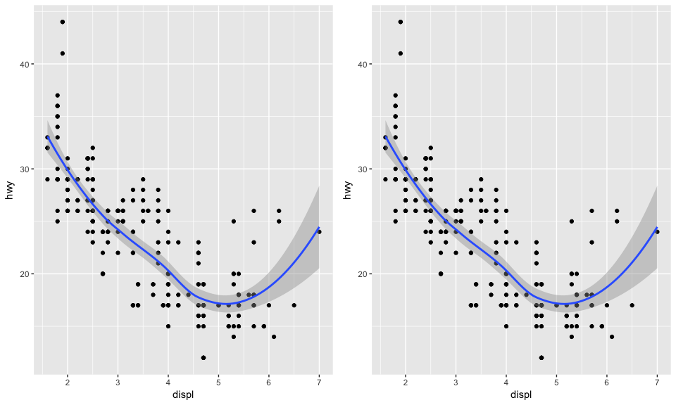

```r
p1 <- ggplot(data = mpg, mapping = aes(x = displ, y = hwy)) +
  geom_point() +
  geom_smooth()

p2 <- ggplot() +
  geom_point(data = mpg, mapping = aes(x = displ, y = hwy)) +
  geom_smooth(data = mpg, mapping = aes(x = displ, y = hwy))

grid.arrange(p1,p2,nrow=1,ncol=2)
```

## 7. Recreate the R code necessary to generate the following graphs.

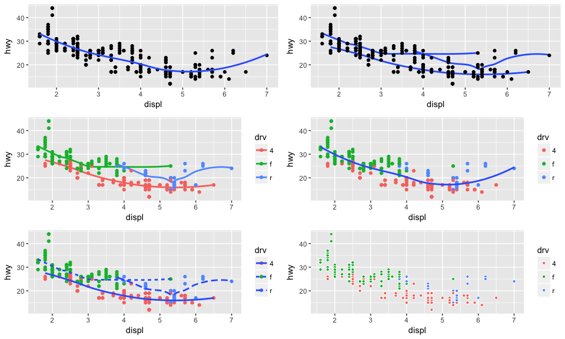

```r
pll1 <- ggplot(data = mpg, mapping = aes(x = displ, y = hwy)) +
  geom_point() +
  geom_smooth(se=FALSE)
pll2 <- ggplot(data = mpg, mapping = aes(x = displ, y = hwy)) +
  geom_smooth(mapping = aes(group=drv),se=FALSE) +
  geom_point()
pll3 <- ggplot(data = mpg, mapping = aes(x = displ, y = hwy,color=drv)) +
  geom_smooth(mapping = aes(group=drv),se=FALSE) +
  geom_point()
pll4 <- ggplot(data = mpg, mapping = aes(x = displ, y = hwy)) +
  geom_point(mapping=aes(color=drv)) +
  geom_smooth(se=FALSE)
pll5 <- ggplot(data = mpg, mapping = aes(x = displ, y = hwy)) +
  geom_point(mapping=aes(color=drv)) +
  geom_smooth(mapping=aes(linetype=drv),se=FALSE)
pll6 <- ggplot(data = mpg, mapping = aes(x = displ, y = hwy, fill=drv)) +
  geom_point(shape=21,color="white") #the point is letting shape and color go outside of aes()

grid.arrange(pll1,pll2,pll3,pll4,pll5,pll6,nrow=3,ncol=2)
```

# 3.7.1 Exercises

## 1. What is the default geom associated with stat_summary()? How could you rewrite the previous plot to use that geom function instead of the stat function?

```r
ggplot(data = diamonds) +
  stat_summary(
    mapping = aes(x = cut, y = depth),
    fun.ymin = min,
    fun.ymax = max,
    fun.y = median
  )
summary(diamonds)
ggplot(data = diamonds) +
  geom_pointrange(mapping = aes(x=cut,y=depth),stat = "identity")

?geom_pointrange
```

[output not shown]

## 2. What does geom_col() do? How is it different to geom_bar()?

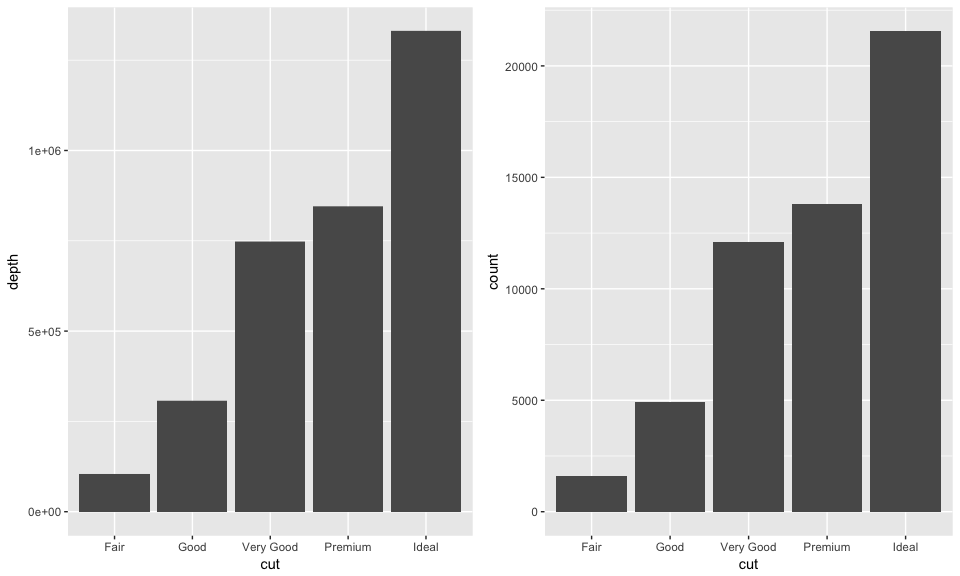

```r
aa1 <- ggplot(data=diamonds) +
  geom_col(mapping = aes(x=cut,y=depth))

aa2 <- ggplot(data=diamonds) +
  geom_bar(mapping = aes(x=cut))

grid.arrange(aa1,aa2,nrow=1,ncol=2)
```

```r
?geom_boxplot
#geom_bar uses stat_count by default: it counts the number of cases at each x position. geom_col uses stat_identity: it leaves the data as is.
```

## 3. Most geoms and stats come in pairs that are almost always used in concert. Read through the documentation and make a list of all the pairs. What do they have in common?

### a) geom_bar/geom_col/stat_count

### b) geom_freqpoly/geom_histogram/stat_bin

### c) geom_boxplot/stat_boxplot

### d) geom_smooth/stat_smooth

## 3. What variables does stat_smooth() compute? What parameters control its behaviour?

```r
?stat_smooth
#It use predict to compute the standard errors
#'se' is applied to control its behaviour
```

## 4. In our proportion bar chart, we need to set group = 1. Why? In other words what is the problem with these two graphs?

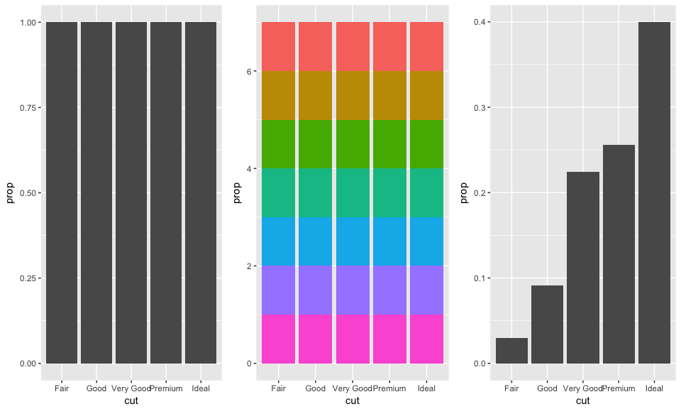

```r
a11 <- ggplot(data = diamonds) +
  geom_bar(mapping = aes(x = cut, y = ..prop..))
a22 <- ggplot(data = diamonds) +
  geom_bar(mapping = aes(x = cut, fill = color, y = ..prop..), show.legend = FALSE)
a33 <- ggplot(data = diamonds) +
  geom_bar(mapping = aes(x = cut, y = ..prop..,group=1))

grid.arrange(a11,a22,a33,nrow=1,ncol=3)
```

# 3.8.1 Exercise

## 1. What is the problem with this plot? How could you improve it?

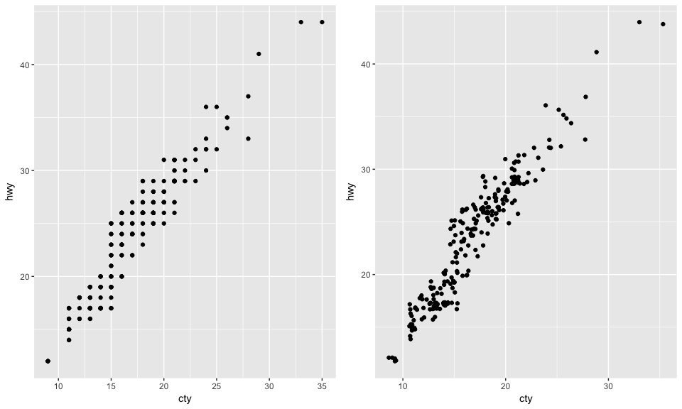

```r
b11 <- ggplot(data = mpg, mapping = aes(x = cty, y = hwy)) +
  geom_point()
b22 <- ggplot(data = mpg, mapping = aes(x = cty, y = hwy)) +
  geom_point(position = "jitter")
grid.arrange(b11,b22,nrow=1,ncol=2)
```

```r
#The problem is many points overlapping each other, which is known as 'overplotting'; I can avoid this gridding by setting the position adjustment to “jitter”.
```

## 2. What parameters to geom_jitter() control the amount of jittering?

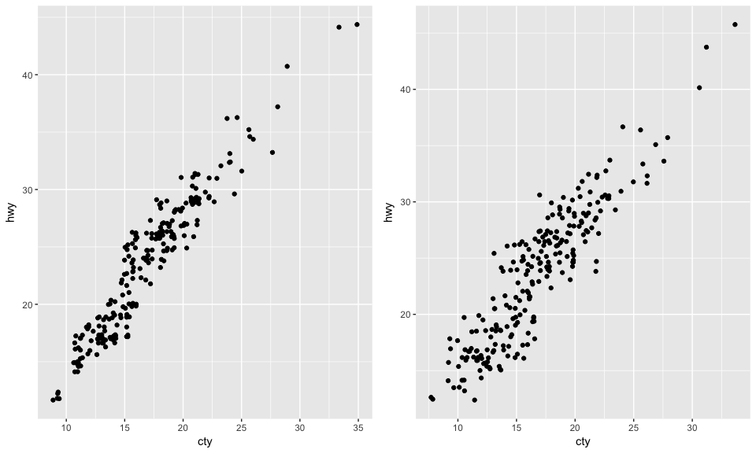

```r
#width and height
b22 <- ggplot(data = mpg, mapping = aes(x = cty, y = hwy)) +
  geom_jitter()
b23 <- ggplot(data = mpg, mapping = aes(x = cty, y = hwy)) +
  geom_jitter(width = 2,height = 2)

grid.arrange(b22,b23,nrow=1,ncol=2)
```

## 3. Compare and contrast geom_jitter() with geom_count().

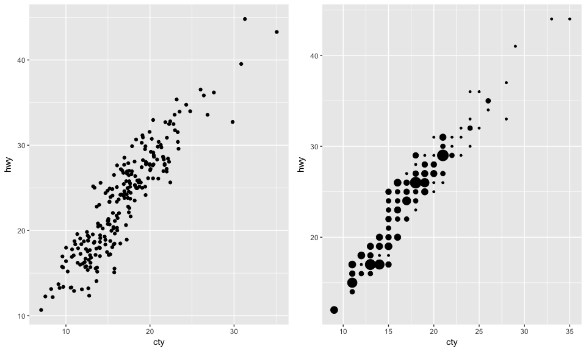

```r
a23 <- ggplot(data = mpg, mapping = aes(x = cty, y = hwy)) +
  geom_jitter(width = 2,height = 2)
a24 <- ggplot(data = mpg, mapping = aes(x = cty, y = hwy)) +
  geom_count(show.legend = FALSE)

grid.arrange(a23,a24,nrow=1,ncol=2)
```

## 4. What’s the default position adjustment for geom_boxplot()? Create a visualisation of the mpg dataset that demonstrates it.

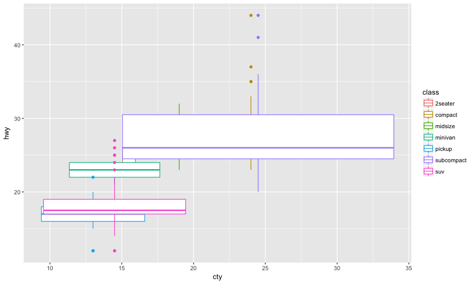

```r
ggplot(data = mpg, mapping = aes(x = cty, y = hwy,color=class)) +
  geom_boxplot()
```

```r
#it relys on the value of x-axies
```

# 3.9.1 Exercises

## 1. Turn a stacked bar chart into a pie chart using coord_polar().

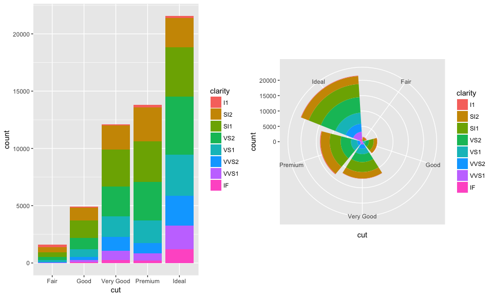

```r
a39_1 <- ggplot(data = diamonds) + geom_bar(mapping = aes(x = cut, fill = clarity))

a39_2 <- ggplot(data = diamonds) + geom_bar(mapping = aes(x = cut, fill = clarity)) + coord_polar()

grid.arrange(a39_1,a39_2,nrow=1,ncol=2)
```

##2. What does labs() do? Read the documentation.

```r
?labs
#Modify axis, legend, and plot labels
```